# S1.2 — `seed_centroids()`: centroidi per regione (densità, composizione, distanza minima)

geo_spatialtrans — report di step

Published

October 8, 2026

**Sessione**: S1.2 · 2026-10-08 · branch `step1-cell-layer` · pre-registrazione `60187fb` · stato pre-revisione `6316790` · chiusura: commit successivo (sha nella nota di sessione). **Obiettivo unico**: `seed_centroids(regions, cell_types, region_composition, random_seed)` in `R/04b2_seed_centroids.R`. Fuori scope: Voronoi (S1.3), nuclei e nuclei pallidi (S1.4, BL-035), preset e orchestratore (S1.5), implementazione di BL-042/BL-043.

**In breve.** Dopo le correzioni della revisione avversariale la funzione fa ciò che dichiara: check C 77/77 PASS, 8/8 mutanti rilevati, 450 000 punti in 4.6 s. Sul piano biologico il Poisson-disk con la regola del design (d = ⅔·eq_radius) è giustificato **al limite**: secondo la definizione pre-registrata batte la CSR in 4 archetipi su 6 (soglia 4, previsti 5); con 3 delle 4 varianti di sensibilità scende a 3/6. La regola stessa è adeguata solo in A1 e A2. In 5 archetipi su 6 la distanza minima preferita dai dati (d*) è più piccola della regola; in modo descrittivo segue meglio la taglia del nucleo che la densità. In tutti gli archetipi resta un’aggregazione (g(r) > 1 fra 5 e 30 µm) che nessun processo hard-core omogeneo produce.

# 1. Pre-registrazione

Testo integrale: `results/S1.2/S1.2_preregistration.md`, committato **prima** del codice (`60187fb`). Approvazione di Luca in chat il 2026-10-08 («approvo»), dopo tre decisioni prese in apertura:

| Decisione | Contenuto | Chi |
| --- | --- | --- |
| BL-042 | stride dai metadati di generatori/loader; stride stimato > 1 non dichiarato → errore (implementazione in S1.1b/S1.5) | Luca |
| BL-043 | componenti sotto soglia assegnate alla regione adiacente con il confine condiviso più lungo; escluse solo se isolate (implementazione in S1.1b/S1.5) | Claude su delega di Luca |
| D3 | densità di una regione mista = media **armonica** 1/Σ(f_i/ρ_i) (frazioni per numero di cellule) | Luca |

Deviazioni dal design §5.2 approvate: (1) RSA a n fissato invece di Bridson — Bridson è massimale e con d = ⅔·eq_radius satura a ≈ 5× la densità target; a n target il riempimento è η = 1/9 per ogni densità, lontano dal limite RSA 0.547 (Feder 1980, doi:10.1016/0022-5193(80)90358-6); (2) arrotondamento stocastico non distorto (Bernoulli per regione, Madow per tipo); (3) distanza minima globale con d_ij = (d_i+d_j)/2; (4) `min_dist_um` opzionale; (5) preset rinviati a S1.5; (6) `n_failed` registrato invece del ciclo infinito.

Parametri per archetipo (densità totale manuale B-043…B-048, intervallo [evidenti, totale]):

```r
x <- AR[, c("archetype", "tot", "evid", "eq_r", "d_rule", "d_nuc", "primary")]
x$eq_r <- round(x$eq_r, 2); x$d_rule <- round(x$d_rule, 2)
names(x) <- c("arch.", "totale /mm²", "evidenti /mm²", "eq_radius (µm)", "d regola ⅔·eq_r (µm)", "d nucleare (µm, provv.)", "segmentatore primario")
kable(x)
```

| arch. | totale /mm² | evidenti /mm² | eq_radius (µm) | d regola ⅔·eq_r (µm) | d nucleare (µm, provv.) | segmentatore primario |
| --- | --- | --- | --- | --- | --- | --- |
| A1 | 12419 | 10291 | 5.06 | 3.38 | 4.1 | cellpose_rgb |
| A2 | 8924 | 7376 | 5.97 | 3.98 | 6.3 | cellpose_rgb |
| A3 | 3100 | 2311 | 10.13 | 6.76 | 6.3 | cellpose_rgb |
| A4 | 28096 | 26844 | 3.37 | 2.24 | 4.2 | spaceranger |
| A5 | 1185 | 953 | 16.39 | 10.93 | 11.3 | cellpose_rgb |
| A6 | 988 | 906 | 17.95 | 11.97 | 4.8 | spaceranger |

**Definizioni operative aggiunte dopo l’approvazione e prima del run** (nelle intestazioni di `R/testing/test_S1.2.R` e `tools/S1.2_checkB.R`; specificano input e stimatori senza cambiare soglie): catalogo di test non biologico (T1–T4) e composizioni dei sintetici; C4c valutato su I1–I4; finestra = maschera di tessuto R2; banda della `pcf` **fissata per ROI** a quella di Stoyan del pattern reale primario (altrimenti la densità diversa fra reale e simulato cambierebbe il lisciamento); D integrato su r = 0.5…30 µm (g(0) non stimabile); griglia CP-2 con `max_attempts_factor = 50` e arresto alla prima replica non piazzata; B1a con tolleranza ±1 cellula/area. **Due di queste erano sbagliate.** La tolleranza di B1a è discussa in §3.1. La seconda: la versione pre-revisione integrava D da r = 0.5 «perché g(0) non è stimabile». Era una deviazione non necessaria dalla pre-registrazione (∫₀³⁰), perché g(0) è finito per tutti i pattern, e cambiava l’esito di CP-1 (RA-checkB-07). Questo report usa la definizione pre-registrata; la variante da 0.5 è riportata come sensibilità. Gli script di analisi sono entrati in git solo insieme ai risultati (`6316790`), quindi da git non si può verificare che le loro definizioni precedessero il run (RA-checkB-20, BL-059). Nella tabella g(r) della pre-registrazione, A4 e A6 riportano valori Cellpose, mentre il riferimento usato è SR4 (RA-checkB-04).

# 2. Check C — correttezza software

Comando: `R_LIBS_SITE=/nonexistent R_LIBS_USER=/nonexistent Rscript --vanilla R/testing/test_S1.2.R` (≈ 4 min). Ogni check ha un **mutante** (`tools/S1.2_mutants.R`) che sostituisce un solo helper e deve farlo fallire (BL-048): un check che il suo mutante non fa fallire non ha potere.

```r
agg <- aggregate(status ~ check, tr[tr$check != "MUT", ], function(s) sprintf("%d/%d PASS", sum(s == "PASS"), length(s)))
kable(agg, col.names = c("check", "esito"))
```

| check | esito |
| --- | --- |
| C-d | 11/11 PASS |
| C-d2 | 5/5 PASS |
| C-in | 8/8 PASS |
| C-mix | 1/1 PASS |
| C-sat | 4/4 PASS |
| C-schema | 14/14 PASS |
| C-seed | 4/4 PASS |
| C-unif | 1/1 PASS |
| C1a | 8/8 PASS |
| C1b | 1/1 PASS |
| C4a | 5/5 PASS |
| C4b | 3/3 PASS |
| C4c | 4/4 PASS |

```r
kable(mu[, c("mutant", "check", "value", "status")], col.names = c("mutante", "check bersaglio", "effetto misurato", "rilevato"))
```

| mutante | check bersaglio | effetto misurato | rilevato |
| --- | --- | --- | --- |
| M1 | C-in | 872 fuori | PASS |
| M2 | C-d | 134 violazioni | PASS |
| M3 | C1b | media 0.0 | PASS |
| M3b | C4b | T3 media 0.0 vs 114.1 | PASS |
| M4 | C-unif | 0/20 p > 0.001 | PASS |
| M5 | C-seed | same=TRUE differ=TRUE state=FALSE absent=FALSE | PASS |
| M7 | C-d2 | max min(d/d_ij) 1.225 (T1-T1,T1-T3,T3-T3) | PASS |
| M6 | C-mix | 5500.0 | PASS |

Mutanti: M1 campionamento sul riquadro; M2 vicini solo nella propria cella; M3 arrotondamento deterministico; M3b largest-remainder deterministico; M4 Bridson troncato a n; M5 `set.seed()` senza ripristino; M6 media aritmetica (design v1.1); M7 regola fra tipi d_ij = max(d_i, d_j). M7 e il check C-d2 sono stati aggiunti dopo la revisione (RA-code-06): C-d controlla solo che le distanze non scendano sotto il minimo, quindi una regola troppo severa passava.

Asserzioni aggiunte o modificate dopo la revisione avversariale, dichiarate qui:

- C-sat riportato all’input pre-registrato (1 × 1 000 µm: la versione pre-revisione usava 1 × 100 µm senza dichiararlo, RA-code-12), più la stessa striscia ruotata di 45°.
- C-d2 con M7.
- C-schema per input factor (RA-code-07 e 08), geometria vuota (RA-code-16) e ordine dei tipi indipendente dalla locale (RA-code-09).
- C-in sugli avversari a densità più alta (RA-code-23).

**C-perf** (processo separato, `/usr/bin/time -v`): 4 000 × 4 000 µm a densità A4 → 449 536 centroidi su 449 536, 580 814 proposte, **4.6 s**, **346 MB** (soglia 120 s, 4 GB): PASS.

Valori significativi: C1b media 474.62 contro 474 ± 4.03 (200 seed); C4b tipo raro T3 114.36 contro 114.1; C-unif p minimo 0.977 (il processo hard-core è sotto-disperso nei quadrati, p ≈ 1 è atteso). C-sat: nella striscia pre-registrata (1 × 1 000 µm, d = 10 µm, 200 cellule target) la funzione piazza 76 cellule, registra le altre come non piazzate ed emette il warning. Ruotata di 45° impiega 17.5 s; prima della correzione RA-code-11 ne impiegava 1 200.

**Tutte le 77 asserzioni**

```r
kable(tr)
```

| check | input | metric | value | threshold | status |
| --- | --- | --- | --- | --- | --- |
| C1a | I1_syn600_c1 | regioni con n != target | 0 | 0 | PASS |
| C1a | I1_syn600_c1 | n_failed | 0 | 0 | PASS |
| C4a | I1_syn600_c1 | max \|n_i - n f_i\| | 0.500 | < 1 | PASS |
| C4c | I1_syn600_c1 | max scarto rel. (3 tipi) | 0.0005 | <= 0.10 | PASS |
| C-in | I1_syn600_c1 | centroidi fuori regione | 0 | 0 | PASS |
| C-d | I1_syn600_c1 | violazioni (31090 coppie) | 0 | 0 | PASS |
| C-d | I1_syn600_c1 | violaz. fra regioni (685 coppie) | 0 | 0 | PASS |
| C-d2 | I1_syn600_c1 | max_k min(d/d_ij) (T1-T1,T2-T2,T3-T3) | 1.0204 | <= 1.05 | PASS |
| C1a | I2_syn600_c2 | regioni con n != target | 0 | 0 | PASS |
| C1a | I2_syn600_c2 | n_failed | 0 | 0 | PASS |
| C4a | I2_syn600_c2 | max \|n_i - n f_i\| | 0.850 | < 1 | PASS |
| C4c | I2_syn600_c2 | max scarto rel. (4 tipi) | 0.0032 | <= 0.10 | PASS |
| C-in | I2_syn600_c2 | centroidi fuori regione | 0 | 0 | PASS |
| C-d | I2_syn600_c2 | violazioni (22035 coppie) | 0 | 0 | PASS |
| C-d | I2_syn600_c2 | violaz. fra regioni (1222 coppie) | 0 | 0 | PASS |
| C-d2 | I2_syn600_c2 | max_k min(d/d_ij) (T1-T1,T2-T2,T3-T3) | 1.0059 | <= 1.05 | PASS |
| C1a | I3_syn600_c3 | regioni con n != target | 0 | 0 | PASS |
| C1a | I3_syn600_c3 | n_failed | 0 | 0 | PASS |
| C4a | I3_syn600_c3 | max \|n_i - n f_i\| | 0.950 | < 1 | PASS |
| C4c | I3_syn600_c3 | max scarto rel. (4 tipi) | 0.0048 | <= 0.10 | PASS |
| C-in | I3_syn600_c3 | centroidi fuori regione | 0 | 0 | PASS |
| C-d | I3_syn600_c3 | violazioni (40380 coppie) | 0 | 0 | PASS |
| C-d | I3_syn600_c3 | violaz. fra regioni (1120 coppie) | 0 | 0 | PASS |
| C-d2 | I3_syn600_c3 | max_k min(d/d_ij) (T1-T1,T3-T3) | 1.0043 | <= 1.05 | PASS |
| C1a | I4_syn600_c4 | regioni con n != target | 0 | 0 | PASS |
| C1a | I4_syn600_c4 | n_failed | 0 | 0 | PASS |
| C4a | I4_syn600_c4 | max \|n_i - n f_i\| | 0.750 | < 1 | PASS |
| C4c | I4_syn600_c4 | max scarto rel. (4 tipi) | 0.0058 | <= 0.10 | PASS |
| C-in | I4_syn600_c4 | centroidi fuori regione | 0 | 0 | PASS |
| C-d | I4_syn600_c4 | violazioni (42145 coppie) | 0 | 0 | PASS |
| C-d | I4_syn600_c4 | violaz. fra regioni (741 coppie) | 0 | 0 | PASS |
| C-d2 | I4_syn600_c4 | max_k min(d/d_ij) (T1-T1,T3-T3) | 1.0024 | <= 1.05 | PASS |
| C-d | mix 1mm2 T1/T3 | violazioni (5910 coppie) | 0 | 0 | PASS |
| C-d2 | mix 1mm2 T1/T3 | max_k min(d/d_ij) (T1-T1,T1-T3,T3-T3) | 1.0019 | <= 1.05 | PASS |
| C-in | adv_donut | fuori regione (n=168) | 0 | 0 | PASS |
| C-in | adv_donut_island | fuori regione (n=176) | 0 | 0 | PASS |
| C-in | adv_L | fuori regione (n=14) | 0 | 0 | PASS |
| C-in | roi_A1_r1 | fuori regione (n=11123) | 0 | 0 | PASS |
| C-d | roi_A4_f1 | violazioni (7614 coppie) | 0 | 0 | PASS |
| C-d | roi_A4_f1 | violaz. fra regioni (511) | 0 | 0 | PASS |
| C1b | 2000x200um2 | media totale (SD 20.5) | 474.62 | 474 ± 4.03 | PASS |
| C4b | 2000x400um2 | media T1 (atteso 5136.7) | 5134.94 | ± 5.59 (3 SE) | PASS |
| C4b | 2000x400um2 | media T2 (atteso 456.6) | 457.90 | ± 4.28 (3 SE) | PASS |
| C4b | 2000x400um2 | media T3 (atteso 114.1) | 114.36 | ± 2.22 (3 SE) | PASS |
| C4a | 2000x400um2 | max \|n_i - n f_i\| | 0.960 | < 1 | PASS |
| C-unif | 1mm2 A1 | seed con p > 0.001 | 20/20 (p min 0.977) | >= 19/20 | PASS |
| C-mix | 1mm2 50/50 | densita’ target; n_target | 1818.18; 1819 | 1818.18; {1818,1819} | PASS |
| C-seed | I1 | same | TRUE | TRUE | PASS |
| C-seed | I1 | differ | TRUE | TRUE | PASS |
| C-seed | I1 | state | TRUE | TRUE | PASS |
| C-seed | I1 | absent | TRUE | TRUE | PASS |
| C-sat | striscia 1x1000 | n_target; n_cells; n_failed | 200; 76; 124 | 200; <= 101; >= 99 | PASS |
| C-sat | striscia 1x1000 | warning emesso; tempo (s) | TRUE; 0.1 | TRUE; < 60 | PASS |
| C-sat | striscia 1x1000 a 45° | n_target; n_cells; n_failed | 200; 72; 128 | 200; <= 101; >= 99 | PASS |
| C-sat | striscia 1x1000 a 45° | warning emesso; tempo (s) | TRUE; 17.5 | TRUE; < 60 | PASS |
| C-schema | I1 | colonne | cell_id,region_id,x,y,cell_type,cluster_id | cell_id,region_id,x,y,cell_type,cluster_id | PASS |
| C-schema | I1 | cell_id == 1..N | TRUE | TRUE | PASS |
| C-schema | I1 | cluster_id coerente | TRUE | TRUE | PASS |
| C-schema | 1mm2 | tipo ignoto -> errore | TRUE | TRUE | PASS |
| C-schema | 1mm2 | densita’ 0 in composizione -> errore | TRUE | TRUE | PASS |
| C-schema | 1mm2 | densita’ < 0 -> errore | TRUE | TRUE | PASS |
| C-schema | 1mm2 | cluster senza composizione -> errore | TRUE | TRUE | PASS |
| C-schema | 1mm2 | frazioni .45/.45 -> warning + normalizzate | TRUE | TRUE | PASS |
| C-schema | 2 regioni | region_id factor -> errore (RA-code-07) | TRUE | TRUE | PASS |
| C-schema | 1mm2 | density factor -> errore (RA-code-08) | TRUE | TRUE | PASS |
| C-schema | 1mm2 | fraction factor -> errore (RA-code-08) | TRUE | TRUE | PASS |
| C-schema | vuota | geometria vuota -> errore (RA-code-16) | TRUE | TRUE | PASS |
| C-schema | 1mm2 | ordine tipi a pari densita’ = ordine C (RA-code-09) | B,a | B,a | PASS |
| C-schema | vuoto | 0 regioni -> 0 righe senza errore | TRUE | TRUE | PASS |
| MUT | M1 | rileva C-in | 872 fuori | check fallisce | PASS |
| MUT | M2 | rileva C-d | 134 violazioni | check fallisce | PASS |
| MUT | M3 | rileva C1b | media 0.0 | check fallisce | PASS |
| MUT | M3b | rileva C4b | T3 media 0.0 vs 114.1 | check fallisce | PASS |
| MUT | M4 | rileva C-unif | 0/20 p > 0.001 | check fallisce | PASS |
| MUT | M5 | rileva C-seed | same=TRUE differ=TRUE state=FALSE absent=FALSE | check fallisce | PASS |
| MUT | M7 | rileva C-d2 | max min(d/d_ij) 1.225 (T1-T1,T1-T3,T3-T3) | check fallisce | PASS |
| MUT | M6 | rileva C-mix | 5500.0 | check fallisce | PASS |

# 3. Check B — plausibilità biologica (A1–A6)

Configurazione: un tipo per archetipo, densità = totale manuale, d = ⅔·eq_radius; 5 ROI R2 da ~1 mm² per archetipo (`results/R2/R2_rois_checked.csv`), 20 repliche per ROI. Riferimento: segmentatore primario (Cellpose-SAM RGB in A1–A3, A5; Space Ranger 4 in A4, A6, decisione R2b), secondario StarDist HE.

```r
x <- S[S$check %in% c("B1a", "B1b", "B2"), c("archetype", "check", "value", "threshold", "status", "predicted")]
kable(x, col.names = c("arch.", "check", "valore", "soglia", "esito", "previsto"), row.names = FALSE)
```

| arch. | check | valore | soglia | esito | previsto |
| --- | --- | --- | --- | --- | --- |
| A1 | B1a | 2/5 | 5/5 (coerenza) | FAIL | PASS |
| A2 | B1a | 3/5 | 5/5 (coerenza) | FAIL | PASS |
| A3 | B1a | 5/5 | 5/5 (coerenza) | PASS | PASS |
| A4 | B1a | 5/5 | 5/5 (coerenza) | PASS | PASS |
| A5 | B1a | 1/5 | 5/5 (coerenza) | FAIL | PASS |
| A6 | B1a | 5/5 | 5/5 (coerenza) | PASS | PASS |
| A1 | B1b | 5/5 (esclusa mediana 0.042) | >= 4/5 | PASS | PASS |
| A2 | B1b | 5/5 (esclusa mediana 0.066) | >= 4/5 | PASS | PASS |
| A3 | B1b | 5/5 (esclusa mediana 0.050) | >= 4/5 | PASS | PASS |
| A4 | B1b | 4/5 (esclusa mediana 0.040) | >= 4/5 | PASS | PASS (al limite) |
| A5 | B1b | 5/5 (esclusa mediana 0.039) | >= 4/5 | PASS | PASS |
| A6 | B1b | 0/5 (esclusa mediana 0.227) | >= 4/5 | FAIL | FAIL |
| A1 | B2 | 0.00 | >= 0.80 PASS; 0.50-0.80 WARN | FAIL | FAIL |
| A2 | B2 | 0.00 | >= 0.80 PASS; 0.50-0.80 WARN | FAIL | FAIL |
| A3 | B2 | 0.02 | >= 0.80 PASS; 0.50-0.80 WARN | FAIL | FAIL |
| A4 | B2 | 0.10 | >= 0.80 PASS; 0.50-0.80 WARN | FAIL | WARN |
| A5 | B2 | 0.18 | >= 0.80 PASS; 0.50-0.80 WARN | FAIL | FAIL |
| A6 | B2 | 0.18 | >= 0.80 PASS; 0.50-0.80 WARN | FAIL | FAIL |

## 3.1 B1a — densità sulla maschera del ROI (coerenza)

Vera per costruzione, e infatti la densità media sulle 20 repliche coincide con il totale manuale entro 0.26 cellule/mm² in 30/30 ROI. L’esito FAIL in A1, A2, A5 viene dalla **tolleranza operativa sbagliata** (±1 cellula/area del ROI): ogni componente connessa della maschera (1–8 per ROI) arrotonda indipendentemente, quindi lo scarto massimo è ± n_regioni/area. Lo scarto massimo osservato è 2.6 cellule/mm² sopra il totale (0.222 %). Non è un difetto del simulatore; la definizione operativa è scritta qui come discrepanza e non corretta a posteriori.

## 3.2 B1b — densità sulle mappe graphclust 8 µm (quantifica BL-043)

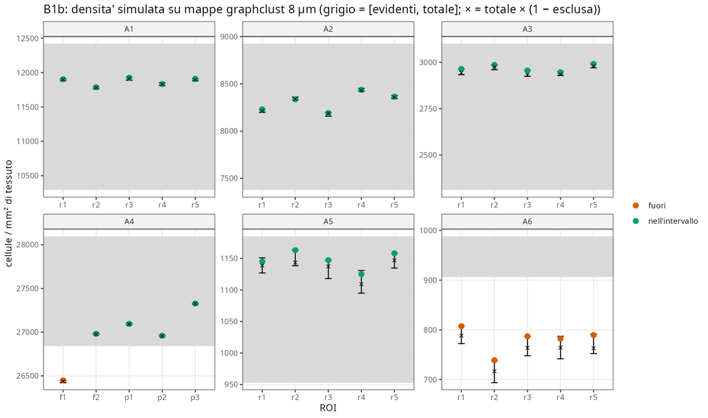

Previsione confermata in tutti e sei gli archetipi, incluso il dettaglio di A4 (un ROI fuori, f1, con frazione esclusa 0.059 > ampiezza dell’intervallo 0.045). In A6 la semantica attuale di §5.1 (componenti < 100 µm² = spazio extracellulare) toglie il 22.7 % delle cellule e porta la densità sotto il limite inferiore in 5/5 ROI. **Conferma la decisione BL-043** (riassegnare le componenti sotto soglia), che quindi non torna a Luca.

## 3.3 B2 — g(r) simulata nell’inviluppo dei 5 ROI reali

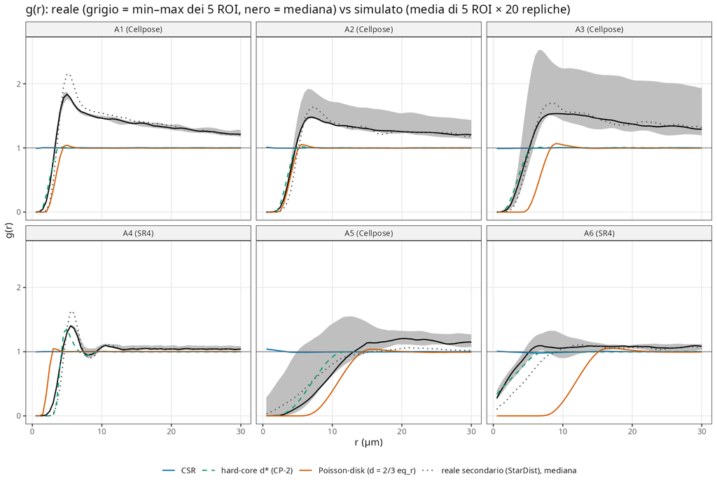

B2 fallisce in tutti gli archetipi, come previsto per cinque di essi; A4, previsto WARN, è FAIL (copertura 0.10). Il revisore lo conferma in 24/24 combinazioni archetipo × banda (copertura massima 0.35). La figura mostra il perché:

L’inviluppo minimo–massimo di 5 ROI è stretto (larghezza mediana su r in (0, 30]: A1 0.08, A2 0.34, A3 0.82, A4 0.07, A5 0.37, A6 0.13); la frazione di r coperta è quindi una soglia severa. La decomposizione per r ≤ 10 e r > 10 µm è in `results/S1.2/S1.2_B2.csv`.

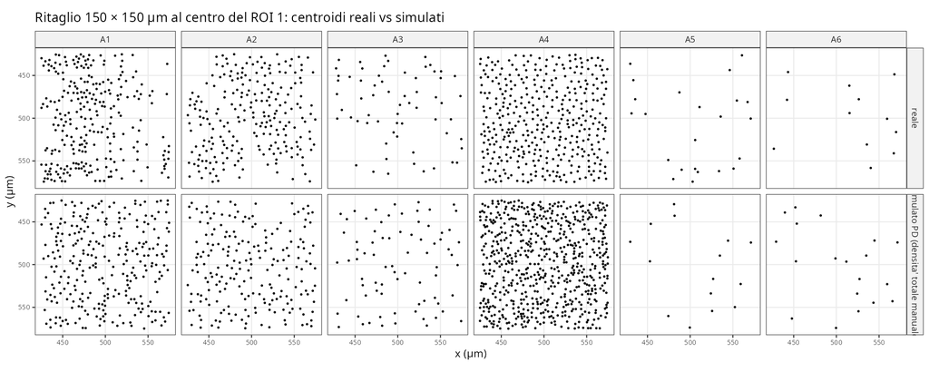

# 4. Controprove

```r
x <- S[grepl("^CP", S$check), c("archetype", "check", "value", "threshold", "status", "predicted")]
kable(x, col.names = c("arch.", "check", "valore", "soglia", "esito", "previsto"), row.names = FALSE)
```

| arch. | check | valore | soglia | esito | previsto |
| --- | --- | --- | --- | --- | --- |
| A1 | CP-1 | 5/5; 0.27 | >= 4/5 e >= 0.25 | PASS | sì |
| A2 | CP-1 | 5/5; 0.58 | >= 4/5 e >= 0.25 | PASS | sì |
| A3 | CP-1 | 3/5; 0.10 | >= 4/5 e >= 0.25 | FAIL | sì |
| A4 | CP-1 | 5/5; 0.66 | >= 4/5 e >= 0.25 | PASS | sì |
| A5 | CP-1 | 4/5; 0.82 | >= 4/5 e >= 0.25 | PASS | sì |
| A6 | CP-1 | 0/5; -6.45 | >= 4/5 e >= 0.25 | FAIL | no |
| tutti | CP-1 | 4/6 | >= 4/6 | PASS | 5/6 (no A6) |
| A1 | CP-2 | 1.07; d* 2.5 (regola 3.38, nucleo 4.1: 1.27) | <= 1.25 adeguata | PASS | adeguata |
| A2 | CP-2 | 0.99; d* 3.5 (regola 3.98, nucleo 6.3: 1.92) | <= 1.25 adeguata | PASS | adeguata |
| A3 | CP-2 | 1.61; d* 3.5 (regola 6.76, nucleo 6.3: 1.44) | <= 1.25 adeguata | FAIL | non adeguata |
| A4 | CP-2 | 5.80; d* 4.0 (regola 2.24, nucleo 4.2: 1.26) | <= 1.25 adeguata | FAIL | non adeguata |
| A5 | CP-2 | 2.12; d* 7.0 (regola 10.93, nucleo 11.3: 2.31) | <= 1.25 adeguata | FAIL | adeguata |
| A6 | CP-2 | 40.84; d* 2.5 (regola 11.97, nucleo 4.8: 5.88) | <= 1.25 adeguata | FAIL | non adeguata |
| A1 | CP-3 | 0.06; 0.08 | < 0.5 | PASS | incerto |
| A2 | CP-3 | 0.05; 0.12 | < 0.5 | PASS | PASS |
| A3 | CP-3 | 0.16; 0.18 | < 0.5 | PASS | PASS |
| A4 | CP-3 | 0.06; 0.19 | < 0.5 | PASS | PASS |
| A5 | CP-3 | 0.10; 0.47 | < 0.5 | PASS | PASS |
| A6 | CP-3 | 0.45; 0.07 | < 0.5 | PASS | incerto |
| tutti | CP-3 | 6/6 | >= 4/6 (previsione) | PASS | >= 4/6 |

## 4.1 CP-1 — Poisson-disk (regola) contro CSR

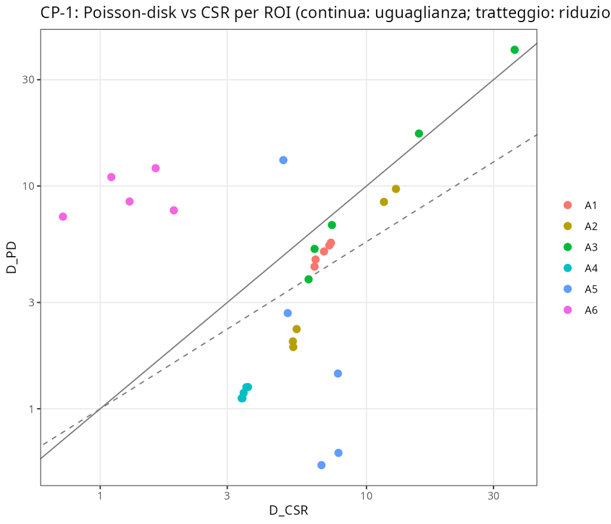

Pre-registrato: giustificato in ≥ 4/6 archetipi, previsto 5/6 (tutti tranne A6). **Esito 4/6 (A1, A2, A4, A5): PASS, ma al limite; la previsione è smentita in A3.** A1 passa con una riduzione mediana di 0.266 contro la soglia di 0.25. Il Poisson-disk vince in 5/5 ROI, ma la discrepanza è dominata dall’aggregazione oltre 5 µm, comune a CSR e Poisson-disk. In A3 la regola dà d = 6.76 µm, troppo grande: vince in 3/5 ROI e riduce D del 10 %. In A6 il Poisson-disk è **7.4 volte peggiore** della CSR (mediana dei rapporti per ROI) (d = 12 µm contro nuclei reali che hanno primi vicini da 3 µm in su). **Sensibilità** (non pre-registrata; varianti del revisore RA-checkB-08 più D da r = 0.5):

| variante | A1 riduzione | CP-1 generale | CP-3 generale |
| --- | --- | --- | --- |
| pre-registrata (D da 0, banda di Stoyan del reale) | 0.266 | **4/6 PASS** | 6/6 |
| D da r = 0.5 | 0.210 | 3/6 FAIL | 5/6 |
| banda × 0.5 (revisore, D da 0.5) | 0.251 | 4/6 PASS | 6/6 |
| banda × 2 (revisore, D da 0.5) | 0.064 | 3/6 FAIL | 5/6 |
| banda propria di ogni pattern (revisore, D da 0.5) | 0.213 | 3/6 FAIL | 5/6 |

Gli altri archetipi sono stabili in tutte le varianti: A2, A4 e A5 sempre giustificati, A3 e A6 mai. **Conclusione**: secondo la regola pre-registrata il Poisson-disk con la regola del design è giustificato in generale, ma il verdetto poggia su un solo archetipo (A1) che sta a cavallo della soglia. Un’affermazione robusta è più ristretta: la distanza minima migliora nettamente la CSR in A2, A4 e A5; non la migliora in A3 e la peggiora in A6.

## 4.2 CP-2 — quale distanza minima vogliono i dati

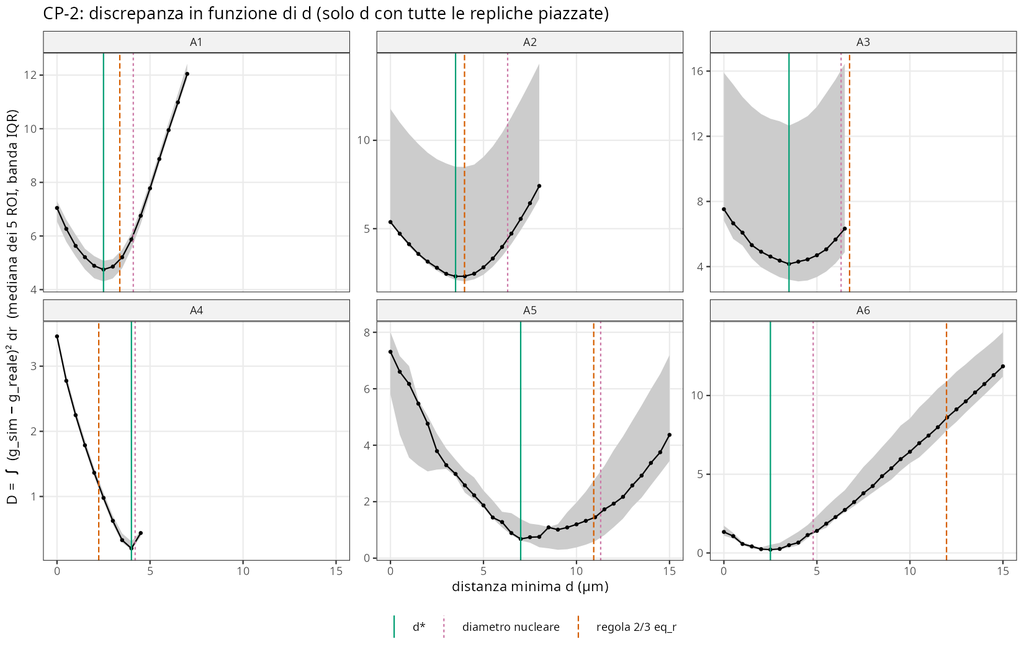

```r
x <- cp2[, c("archetype", "d_star", "d_rule", "ratio_rule", "d_nuc", "ratio_nuc", "frac_D_csr_left_at_dstar", "d_max_feasible")]
x[, -1] <- round(x[, -1], 2)
names(x) <- c("arch.", "d* (µm)", "d regola", "D(regola)/D(d*)", "d nucleare", "D(nucleo)/D(d*)", "D(d*)/D(CSR)", "d max fattibile")
kable(x)
```

| arch. | d* (µm) | d regola | D(regola)/D(d*) | d nucleare | D(nucleo)/D(d*) | D(d*)/D(CSR) | d max fattibile |
| --- | --- | --- | --- | --- | --- | --- | --- |
| A1 | 2.5 | 3.38 | 1.07 | 4.1 | 1.27 | 0.69 | 7.0 |
| A2 | 3.5 | 3.98 | 0.99 | 6.3 | 1.92 | 0.42 | 8.0 |
| A3 | 3.5 | 6.76 | 1.61 | 6.3 | 1.44 | 0.56 | 6.5 |
| A4 | 4.0 | 2.24 | 5.80 | 4.2 | 1.26 | 0.06 | 4.5 |
| A5 | 7.0 | 10.93 | 2.12 | 11.3 | 2.31 | 0.10 | 15.0 |
| A6 | 2.5 | 11.97 | 40.84 | 4.8 | 5.88 | 0.16 | 15.0 |

Previsto: regola adeguata in A1, A2, A5; non adeguata in A3, A4, A6. **Esito: adeguata in A1 e A2; non adeguata in A3, A4, A5, A6**. Cinque archetipi su sei come previsto; A5 smentito (d* = 7 µm contro 10.9 µm della regola).

Il revisore conferma CP-2 in tutte e 5 le varianti (d* si sposta al massimo di 0.5 µm; RA-checkB-09). Due osservazioni **post hoc**, non pre-registrate, da verificare prospetticamente (BL-052):

1. d* cade fra 2.5 e 4 µm in cinque archetipi su sei e a 7 µm in A5, mentre la densità varia di 28 volte. Il rapporto d*/diametro nucleare vale 0.61, 0.56, 0.56, 0.95, 0.62, 0.52 (A1…A6). È solo descrittivo: con n = 6 la correlazione di Spearman è 0.60 con il diametro nucleare e −0.12 con la regola, e la Pearson (0.91) è trainata da A5 (RA-checkB-18). Inoltre i diametri nucleari sono provvisori (BL-025) e i segmentatori perdono nuclei addossati (sotto), quindi d* può essere distorto verso l’alto. La regola ⅔·eq_r fissa invece η = 1/9 per costruzione, cioè lega d alla densità.
2. Anche con d* resta il 42–69 % della discrepanza della CSR in A1–A3, contro il 6 % in A4 e l’10 % in A5. Negli epiteli e nello stroma la struttura spaziale dominante non è l’esclusione ma l’aggregazione.

## 4.3 CP-3 — il riferimento è abbastanza preciso?

Previsto PASS in ≥ 4/6, A1 e A6 incerti. **Esito 6/6**; A6 è al limite: D(SR4, StarDist) = 0.45 × D_CSR, e con D da r = 0.5 sale a 0.60 (FAIL). La ragione non è un forte disaccordo fra segmentatori in assoluto: in A6 la CSR è già vicina al reale (D_CSR mediana 1.29, la più bassa). Rispetto all’errore del Poisson-disk, la disaccordanza dei segmentatori è piccola ovunque (D_seg/D_PD ≤ 0.47): **le conclusioni di CP-1 e CP-2 non dipendono dalla scelta del segmentatore**.

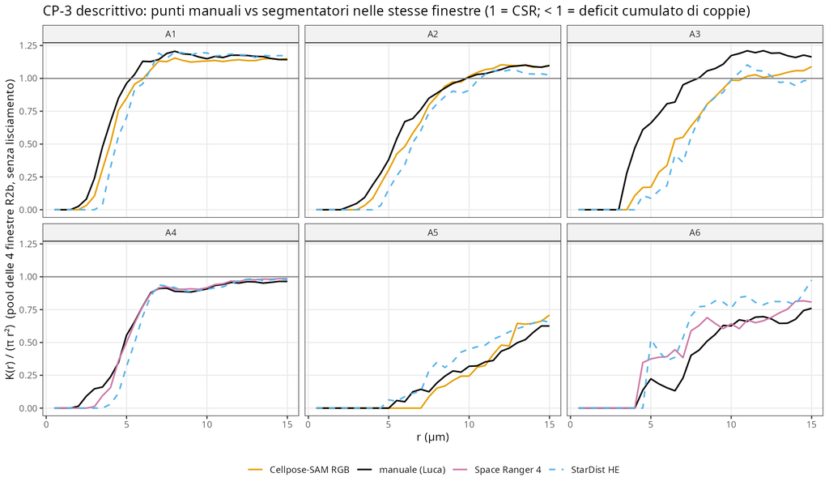

Descrittivo: i punti manuali di Luca nelle 24 finestre R2b (37–162 punti per finestra) contro i segmentatori nelle stesse finestre, in pool di 4 finestre per archetipo. La pre-registrazione chiedeva g(r) in pool. La g(r) in pool (`pool()` con `ratio = TRUE`) però esplode a piccolo r quando una finestra ha pochi nuclei: in A3_w4, con 19 nuclei Cellpose, si ottiene un valore di ~1e48 a r = 2.5 µm, perché i denominatori sono quasi nulli. La figura e la tabella usano quindi K(r)/(πr²) in pool, che non è lisciata e ha come denominatore l’area. È una deviazione dichiarata; la g(r) in pool resta in `results/S1.2/S1.2_manual_pcf.csv`.

```r
x <- mk[!grepl("@", mk$source) & mk$r %in% c(2, 3, 5), ]; x$K_over_pir2 <- round(x$K_over_pir2, 3)
kable(reshape(x, idvar = c("archetype", "source"), timevar = "r", direction = "wide"), row.names = FALSE,
      col.names = c("arch.", "fonte", "r = 2 µm", "r = 3 µm", "r = 5 µm"))
```

| arch. | fonte | r = 2 µm | r = 3 µm | r = 5 µm |
| --- | --- | --- | --- | --- |
| A1 | manual | 0.025 | 0.239 | 0.962 |
| A1 | cellpose_rgb | 0.000 | 0.104 | 0.850 |
| A1 | stardist_he | 0.000 | 0.000 | 0.703 |
| A2 | manual | 0.000 | 0.048 | 0.383 |
| A2 | cellpose_rgb | 0.000 | 0.000 | 0.304 |
| A2 | stardist_he | 0.000 | 0.000 | 0.156 |
| A3 | manual | 0.000 | 0.000 | 0.660 |
| A3 | cellpose_rgb | 0.000 | 0.000 | 0.172 |
| A3 | stardist_he | 0.000 | 0.000 | 0.087 |
| A4 | manual | 0.014 | 0.147 | 0.556 |
| A4 | spaceranger | 0.000 | 0.012 | 0.501 |
| A4 | stardist_he | 0.000 | 0.000 | 0.319 |
| A5 | manual | 0.000 | 0.000 | 0.000 |
| A5 | cellpose_rgb | 0.000 | 0.000 | 0.000 |
| A5 | stardist_he | 0.000 | 0.000 | 0.063 |
| A6 | manual | 0.000 | 0.000 | 0.223 |
| A6 | spaceranger | 0.000 | 0.000 | 0.375 |
| A6 | stardist_he | 0.000 | 0.000 | 0.523 |

Gli umani cliccano più coppie a 3–5 µm dei segmentatori in A1–A4 (i segmentatori perdono nuclei addossati), quindi il deficit a corto raggio del riferimento automatico è un po’ esagerato. In A6 nessuna fonte ha coppie sotto 3 µm. Il valore apparente g(0.5–2 µm) ≈ 0.3–0.6 del riferimento SR4 su 1 mm² è un **artefatto del lisciamento** (banda ≈ 2 µm a densità bassa): la frazione di nuclei SR4 con primo vicino < 2 µm è 0.000 (ricalcolo diretto con `nndist`). Lo stesso stimatore è applicato a reale e simulato, quindi il confronto resta equo, ma la risoluzione della g(r) in A5–A6 è ~2 µm. Il revisore, con un estimatore indipendente (FFT della maschera), riproduce la g(r) del riferimento entro |Δg| ≤ 0.0021 su 60/60 pattern. Mostra però che il lisciamento attenua anche il picco di A3 (g(6) grezza 1.63 contro 1.27 lisciata; RA-checkB-03).

# Verdetto

**Chiuso con riserve.** Dopo le correzioni dei 4 bug trovati dalla revisione, `seed_centroids()` è corretta per ciò che dichiara: check C completo, mutanti rilevati, prestazioni circa 26 volte sotto il budget. Le previsioni pre-registrate sono state smentite in CP-1 (A3), in CP-2 (A5), in B2 (A4) e, per la sola definizione operativa, in B1a. Le smentite sono dati, non errori; le attese non sono state modificate. Il Poisson-disk con la regola del design è giustificato al limite (4/6), e la regola è adeguata solo in 2 archetipi su 6.

Riserve:

- **R-1 (decisione di Luca)**: la regola di default d = ⅔·eq_radius va sostituita. Opzioni: `min_dist_um` per archetipo da dati (d* come riga di BIO_REFERENCES con script e dataset), oppure una regola legata al nucleo (d ≈ k·diametro nucleare, k da stimare prospetticamente: post hoc 0.52–0.62, A4 0.95). Fino ad allora la regola resta il default della funzione ma i preset S1.5 non possono usarla.
- **R-2**: l’aggregazione oltre 5 µm (A1–A3 soprattutto) non è riproducibile da un processo omogeneo dentro una regione. Va verificato in S1.5 se emerge dalla struttura in regioni delle mappe reali (densità diverse per cluster), oppure se serve un processo di cluster (BACKLOG).
- **R-3**: B1a, tolleranza operativa sbagliata (±1/area invece di ±n_regioni/area): discrepanza di definizione, non del codice.
- **R-4**: il lisciamento della g(r) (banda di Stoyan 0.4–2.5 µm) limita la risoluzione a ~2 µm in A5–A6 e attenua i picchi (anche in A3). I d* hanno questa incertezza (BL-053).
- **R-6**: ordine di posizionamento per densità decrescente: un tipo grande e raro in una miscela densa resta per il 78–88 % non piazzato; ponendo prima i tipi grandi si scende a 0 (RA-code-10, BL-055). Questa scelta va decisa prima dei preset di S1.5 (A5: neuroni).
- **R-7**: effetto di bordo dell’RSA: +10 % di densità entro 1 µm dal bordo; fra regioni confinanti, asimmetria che dipende dall’ordine (RA-code-19, BL-056). Rilevante per S1.3.
- **R-5**: BL-043 confermata dai dati (B1b A6 0/5); l’implementazione resta da fare (S1.1b o S1.5).

# Revisione avversariale

```r
rv <- list.files(file.path(RES, "review"), pattern = "^S1.2_adversarial_review_.*\\.csv$", recursive = TRUE, full.names = TRUE)
if (length(rv)) {
  R <- do.call(rbind, lapply(rv, function(f) read.csv(f, stringsAsFactors = FALSE)))
  kable(as.data.frame(table(esito = R$outcome)))
} else cat("Revisione in corso.")
```

| esito | Freq |
| --- | --- |
| bug | 4 |
| confermato | 23 |
| discrepanza | 1 |
| rilievo di metodo | 16 |

Due revisori indipendenti (sotto-agenti, codice proprio in Python/R, scrittura limitata a `results/S1.2/review/<track>/`) hanno lavorato sul commit `6316790`.

- **Track code** (23 rilievi): ha rilanciato il test (63/63, CSV identici byte per byte) e confermato C1b (474.6; con 1 000 seed 473.2, z = −1.34), Madow (inclusioni 0.588/0.030/0.471/0.911 contro 0.59/0.03/0.47/0.91) e C-perf. Ha mostrato che i mutanti falliscono per la ragione giusta. Ha trovato **4 bug**: input factor (due varianti), budget delle proposte sui poligoni ruotati (1 200 s), memoria con regioni lontanissime. Ha trovato anche **1 deviazione non dichiarata** (C-sat su 1 × 100 µm invece di 1 × 1 000 µm) e 8 rilievi di metodo.
- **Track checkB** (21 rilievi): ha ricalcolato tutti i 30 ROI, i 60 pattern reali e le 1 020 righe modello. D coincide entro 1e-13 e il sommario per 38/38 righe; con un estimatore proprio riproduce la g(r) entro 0.0021; con scipy riproduce in modo indipendente B1b (frazioni escluse 30/30). Ha trovato la deviazione «D da r = 0.5», che cambiava CP-1 da 4/6 a 3/6, e la fragilità del verdetto generale di CP-1. Ha segnalato anche i numeri casuali comuni in B1b (seed 42 in tutti i ROI: 29/30 sopra l’atteso) e il ridimensionamento della lettura di d*.

**Azioni.** Tutti i bug sono stati corretti, tranne quello di memoria, latente, per cui c’è un warning e BL-057. La deviazione su C-sat è corretta; D è tornato alla definizione pre-registrata, con la variante da r = 0.5 come sensibilità. I rilievi di metodo sono finiti nel report o in BACKLOG. **Verifica delle correzioni** (`tools/S1.2_fixcheck.R`): con il codice corretto check B e controprove rifatti da zero danno 60/60 unità di simulazione identiche bit per bit (max |Δg| = 0), 58/58 asserzioni comuni identiche e B1b 30/30 identico. Le correzioni non hanno cambiato nessun risultato numerico. È cambiato solo l’esito di CP-1 e CP-3, per il ritorno alla definizione pre-registrata di D.

```r
kable(act, col.names = c("rilievo", "esito del revisore", "azione", "dove"))
```

[output not shown]

**Tutti i rilievi**

```r
if (length(rv)) kable(R[, intersect(c("id", "task", "claim", "reported", "recomputed", "outcome", "note"), names(R))])
```

| id | task | claim | reported | recomputed | outcome | note |
| --- | --- | --- | --- | --- | --- | --- |
| RA-checkB-01 | 1 | Riferimento reale: finestra, orientazione (y), unita’ e n dei nuclei corretti in real_pcf.rds | n primario/secondario e area_mm2 in real_pcf.rds (30 ROI x 2 segmentatori) | n identico in 59/60 pattern (A6 r3 primario 1081 vs 1080: 1 nucleo sul bordo di un pixel); area della finestra identica in 30/30 (\|diff\| 0); con y NON invertita i nuclei fuori maschera salirebbero d… | confermato | Controprova y-flip discriminante solo dove la maschera e’ asimmetrica (A1, A2, A5); in A3, A4, A6 la maschera e’ quasi piena e l’ISE con y specchiata resta <= 0.14: li’ l’orientazione e’ confermata da… |
| RA-checkB-02 | 1 | g(r) reale = pcf spatstat translate, divisor d, banda bw.stoyan del primario | real_pcf.rds $primary$g e $secondary$g, r = 0..30 passo 0.5 | stimatore indipendente (numpy/scipy: coppie cKDTree, covarianza d’insieme FFT della maschera, Epanechnikov sd = bw, divisore d, massa del kernel rinormalizzata su [0,inf)): max\|dg\| <= 0.0021 su r in… | confermato | Senza correzione a r=0 le differenze salgono a 0.11-0.18 in A5/A6 (solo r < h): il risultato dipende dal default zerocor di spatstat.explore 3.8-2 (avviso ‘default settings have changed for pcf.ppp >=… |
| RA-checkB-03 | 1 | Le differenze tra g lisciata e g grezza sono dovute al solo lisciamento | report §3.4/R-4: risoluzione ~2 um in A5-A6 | stimatore ad anelli senza lisciamento (mediana 5 ROI): A6 g(2) 0.00 vs 0.56 lisciata, g(6) 1.53 vs 1.07; A5 g(4) 0.00 vs 0.07; A3 g(4) 0.36 vs 0.57, g(6) 1.63 vs 1.27; a r = 30 accordo entro 0.03 (A1-… | rilievo di metodo | Il lisciamento attenua il picco del primo vicino anche in A3 (banda sd 1.0 um, semi-ampiezza 2.3 um), non solo in A5-A6 come scritto in R-4. Nessun errore di finestra o di unita’: le differenze sono c… |
| RA-checkB-04 | 1 | I valori di riferimento g(2), g(4), g(6), g(30) della pre-registrazione coincidono con real_pcf.rds | prereg: g(2) 0.17/0.02/0.04/-/0.01; g(4) 1.57/0.65/0.57/-/0.07; g(6) 1.68/1.42/1.27/-/0.20; g(30) 1.21/1.21/1.29/-/1.15 (A1,A2,A3,A5) | mediane da real_pcf.rds e dal mio stimatore: identiche alle due cifre per A1, A2, A3, A5; A4 e A6 differiscono (A4 g(4) 0.80 vs 0.54; A6 g(2) 0.56 vs 0.71) perche’ il primario e’ passato a Space Range… | confermato | Il cambio di primario in A4/A6 e’ dichiarato (decisione R2b 2026-10-07); la tabella dei valori di riferimento della pre-registrazione riporta pero’ ancora ‘Cellpose’ per tutti gli archetipi: i numeri … |
| RA-checkB-05 | 2 | D = trapezi su r = 0.5..30 di (g_sim - g_reale)^2 per ogni (ROI, modello) | S1.2_sim_models.csv colonna D (1020 righe) | ricalcolo da sim/*.rds + real_pcf.rds: max\|dD\| = 1.2e-13 su 1020/1020 righe, nessuna discordanza di NA; S1.2_pcf_curves.csv identico agli rds (max\|dg\| = 0) | confermato | rv_task2_recompute.py, rv_task2_consistency.csv |
| RA-checkB-06 | 2 | Tabella S1.2_checkB_summary.csv (B1a, B1b, B2, CP-1, CP-2, CP-3) | 38 righe value/status | 38/38 righe identiche per valore e per esito | confermato | rv_task2_summary_compare.csv |
| RA-checkB-07 | 2,5 | CP-1 in generale: Poisson-disk giustificato in 3/6 archetipi -> FAIL | 3/6 FAIL; A1 5/5, riduzione mediana 0.21 | con l’integrale letterale della pre-registrazione (r da 0, trapezi passo 0.5): A1 riduzione 0.266 -> PASS, generale 4/6 -> PASS. g(0) e’ finita e ben definita con questo stimatore (reale 0 in A1-A4, C… | rilievo di metodo | La pre-registrazione scrive D = integrale da 0 a 30; il codice e il report (§2) usano r = 0.5..30 con la motivazione ‘g(0) non stimabile’, che non regge con i valori osservati. La scelta e’ dichiarata… |
| RA-checkB-08 | 4,5 | CP-1 robusto alla banda | 3/6 (A2, A4, A5 PASS) | A1 riduzione mediana: x0.5 0.251 (PASS), x1 0.210, x2 0.064, banda propria per pattern 0.213; generale 4/6 PASS a x0.5, 3/6 a x1, x2 e con banda propria. A2, A4, A5 PASS e A3, A6 FAIL in tutte e 5 le … | rilievo di metodo | La conclusione ‘Poisson-disk non giustificato in generale’ poggia su A1, che sta a 0.04 dalla soglia 0.25 e passa la soglia con 2 delle 5 varianti. Va riportata come verdetto al limite, non come sment… |
| RA-checkB-09 | 2,4,5 | CP-2: regola 2/3 eq_r adeguata solo in A1 e A2 | rapporti 1.07, 0.99, 1.61, 5.80, 2.12, 40.82; d* 2.5/3.5/3.5/4.0/7.0/2.5 | ricalcolo identico; con banda x0.5/x2/propria/r da 0: A1, A2 PASS e A3-A6 FAIL sempre (rapporto min fra le varianti: A3 1.58, A4 4.37, A5 2.09, A6 29.1); d* si sposta al massimo di 0.5 um | confermato | Il rapporto di A2 < 1 nasce dal fatto che D_regola viene dal modello PD (d = 3.98, max_attempts_factor 1000, seed propri) e d* dalla griglia: e’ coerente con la definizione. |
| RA-checkB-10 | 2,5 | CP-2: griglia con max_attempts_factor = 50 e arresto alla prima replica non piazzata | dichiarato nel report §2 come definizione operativa, assente nella pre-registrazione | d massimo fattibile 7.0/8.0/6.5/4.5/15/15 um; d* e’ interno in tutti gli archetipi (D cresce per >= 1 passo oltre d*: A4 0.20 -> 0.44 a 4.5); rigenerando con lo stesso codice fattibilita’ e numero di … | confermato | La deviazione non altera d* ne’ gli esiti: con un fattore piu’ alto si aggiungerebbero solo d oltre il minimo. In A1 e A5 il minimo e’ piatto (A1: 4.75 a 2.5 vs 4.86 a 3.0; A5: 0.68-0.75 fra 7.0 e 8.0… |
| RA-checkB-11 | 5 | Banda fissata per ROI (bw di Stoyan del primario reale applicata a reale secondario e simulati) | dichiarato nel report §2; la pre-registrazione dice solo ‘stesso stimatore e stessa finestra’ | con la banda di Stoyan propria di ciascun pattern (default spatstat): CP-1 3/6 (A1 0.213), CP-2 identico, CP-3 5/6 | confermato | La scelta e’ ragionevole e non cambia alcun esito. |
| RA-checkB-12 | 2,5 | B1a FAIL in A1, A2, A5 (2/5, 3/5, 1/5) per tolleranza operativa sbagliata, non per il simulatore | report §3.1 e R-3 | media sulle 20 repliche entro 2.2e-4 relativo dal totale in 30/30 ROI; eccesso massimo 2.05 cellule (A5) oltre totale x area, compatibile con l’arrotondamento indipendente di piu’ componenti della mas… | confermato | La definizione ‘vera per costruzione’ della pre-registrazione era sbagliata (il valore target coincide con l’estremo superiore dell’intervallo). E’ dichiarato nel report, non e’ nell’elenco di conclus… |
| RA-checkB-13 | 3 | B1b: frazione esclusa e densita’ attesa totale x (1 - esclusa) sui 30 ROI graphclust | S1.2_B1b.csv frac_excluded, area_total_mm2, expected | componenti 4-connesse per cluster con scipy.ndimage.label, escluse se < 100 um^2 (solo singoletti a 8 um): max\|d frac\| = 4.7e-16, area identica, atteso identico in 30/30; stride 1 in 30/30 | confermato | Mediana esclusa per archetipo 0.042/0.066/0.050/0.040/0.039/0.227. rv_task3_b1b.csv |
| RA-checkB-14 | 3,5 | A6 B1b FAIL; A4 PASS al limite (4/5) | A6 0/5 FAIL; A4 4/5 PASS | A6: l’atteso stesso e’ fuori dall’intervallo in 5/5 ROI (esclusa 0.20-0.27 > 0.083 consentita); anche con 8-connessione (esclusa mediana 0.131) resta FAIL. A4: f1 ha atteso 26383 < 26844 (esclusa 0.05… | confermato | Il FAIL di A6 e’ una proprieta’ della semantica di esclusione di S1.1 (BL-043), non di seed_centroids(). |
| RA-checkB-15 | 3 | Densita’ seed 42 di B1b sopra l’atteso in 29/30 ROI | non discusso | area dei poligoni semplificati = area in pixel (rapporto 1 in 30/30: ipotesi area esclusa); media dei primi 1000 uniformi con seed 42 = 0.488, z medio seed 42 = 0.95; media su 40 seed entro ~1 SE dall… | rilievo di metodo | Lo stesso seed in tutti i ROI produce numeri casuali comuni: i 5 ROI del criterio ‘>= 4/5’ non sono repliche indipendenti. Effetto trascurabile qui (3-26 cellule, molto meno dell’ampiezza dell’interva… |
| RA-checkB-16 | 2,4,5 | B2 FAIL in tutti gli archetipi | copertura PD 0.00/0.00/0.02/0.10/0.18/0.18 | ricalcolo identico; per singolo ROI copertura massima 0.25; con banda x0.5/x2/propria massima 0.35 (A6, x0.5): FAIL in 24/24 combinazioni archetipo x variante | confermato | La copertura dipende di +-1 punto di r (0.017) da differenze di 1e-3 nello stimatore. L’implementazione confronta la media di g_PD sui 5 ROI con l’inviluppo; la pre-registrazione e’ ambigua (media di … |
| RA-checkB-17 | 2,4 | CP-3: riferimento discriminante in 5/6 (A6 FAIL) | A6 0.60, generale 5/6 | A6: 0.595 (x1), 0.438 (x0.5), 0.794 (x2), 0.582 (propria), 0.449 (r da 0): passa la soglia 0.5 con 2 varianti su 5. Generale 5/6 o 6/6, previsione >= 4/6 rispettata sempre | rilievo di metodo | Il FAIL di A6 in CP-3 e’ al limite e dipende dal lisciamento; coerente con la previsione ‘incerto’. |
| RA-checkB-18 | 5 | ’La distanza minima preferita (d*) segue la taglia del nucleo, non la densita’’ | report, In breve | d*/d_nuc = 0.61/0.56/0.56/0.95/0.62/0.52; d*/d_regola = 0.74/0.88/0.52/1.78/0.64/0.21; Spearman d* ~ d_nuc 0.60, d* ~ d_regola -0.12 (n = 6); Pearson 0.91 vs 0.32, trainato da A5 | rilievo di metodo | Supportato come descrizione (5/6 archetipi con d* ~ 0.5-0.6 d_nuc, A4 eccezione), non come risultato testato: n = 6, minimi piatti in A1 e A5, risoluzione ~2 um in A5-A6, d_nuc provvisorio (B-003…B-03… |
| RA-checkB-19 | 4 | Riproducibilita’ delle simulazioni | sim/*.rds (1020 righe) | rigenerate con seed_centroids() e gli stessi seed: 1020/1020 righe presenti, fattibilita’ e repliche identiche, max\|dg\| 2.4e-3 (attribuibile al mio stimatore, verificato contro spatstat::pcf entro 1… | confermato | rv_task4_repro_sim.csv, rv_task4_repro_real.csv |
| RA-checkB-20 | 5 | Definizioni operative ‘fissate prima del run’ | header di tools/S1.2_checkB.R e report §2 | il commit della pre-registrazione (60187fb, 12:25) non contiene lo script; tools/S1.2_checkB.R compare solo in 6316790 (13:19), insieme ai risultati; real_pcf.rds e’ delle 12:36 | rilievo di metodo | Che banda per ROI, r da 0.5, max_attempts_factor 50 e tolleranza B1a siano stati fissati prima del run non e’ verificabile dalla storia git; vale come dichiarazione. Va aggiunto anche che i risultati … |
| RA-checkB-21 | 4,5 | I risultati di check B corrispondono al codice di seed_centroids() in revisione | commit 6316790 (risultati generati 12:36-13:14) | il mio ricalcolo (lanciato 13:23, codice caricato all’avvio) usa R/04b2_seed_centroids.R di 6316790 e riproduce 1020/1020 righe. Alle 14:18 il file e’ stato modificato fuori commit (nuovo argomento ma… | rilievo di metodo | La modifica non e’ mia (questa revisione scrive solo in review/checkB/). Cambia il criterio di arresto: la fattibilita’ della griglia CP-2 (max_attempts_factor 50) e gli n_failed potrebbero cambiare s… |
| RA-code-01 | 4 | test_S1.2.R: 63/63 PASS | 63 asserzioni, 63 PASS, 0 WARN, 0 FAIL | Rilanciato in copia isolata (results/S1.2/review/code/rerun, md5 dei 5 file = commit 6316790): 63/63 PASS in 60 s; S1.2_test_results.csv e S1.2_mutants.csv identici byte per byte a quelli committati (… | confermato | Conferma la riproducibilita’ del test, non il suo potere: vedi RA-code-06, RA-code-12, RA-code-23 |
| RA-code-02 | 3 | C1b non distorsione: 2 000 quadrati da 200 um2 a 1 185/mm2, atteso 474 | media 474.62 (SD 20.5) su 200 seed; soglia 474 +- 4.03 | Seed 1-200 riprodotti esattamente (474.625; SD 20.53). 1 000 seed: media 473.19 (z = -1.34 con SE teorico), SD 19.37 vs teorica sqrt(2000*0.237*0.763) = 19.02 (chi2 sulla varianza p = 0.40); n_failed … | confermato | La SD 20.5 riportata a 200 seed e’ compatibile con la teorica; 3 SE = 4.03 ricalcolato |
| RA-code-03 | 3 | Madow: probabilita’ di inclusione = parti frazionarie (4 tipi) | dichiarato in pre-registrazione (dev. 2); C4b media T1/T2/T3 = 5134.94/457.90/114.36 vs 5136.7/456.6/114.1 | Helper diretto, 2e5 rep, n = 7, f = (.37,.29,.21,.13): p_incl = .5884/.0299/.4711/.9106 vs .59/.03/.47/.91 (max \|z\| = 1.46); somma sempre = n; mai fuori {floor, floor+1}. Pattern congiunti uguali a … | confermato | Solo le marginali sono garantite (le congiunte del sistematico dipendono dall’ordine dei tipi nella composizione): coerente con la pre-registrazione |
| RA-code-04 | 3 | C-perf: 4 000 x 4 000 um a densita’ A4 <= 120 s, <= 4 GB | 449 536 punti, 4.2 s, 365 MB | 3 rilanci di tools/S1.2_perf.R con /usr/bin/time -v: 4.2/4.2/4.3 s (wall 4.62-4.70 s), max RSS 372-374 MB, n_cells = n_target = 449 536 = 4000^2 x 28096e-6 | confermato | Vedi RA-code-15 e RA-code-14 per scenari in cui le prestazioni degradano |
| RA-code-05 | 3 | I 7 mutanti sono cio’ che dicono e il test li rileva per la ragione giusta | 7/7 rilevati (M1 872 fuori, M2 134 violazioni, M3 media 0, M3b T3 0, M4 0/20, M5 state/absent FALSE, M6 5500) | Lettura del codice: ogni mutante sostituisce solo l’helper dichiarato (M3 round, M3b largest remainder, M5 set.seed senza ripristino, M6 media aritmetica = 5500 = .5*1e4+.5*1e3). Rilanciati con verifi… | confermato | M4 (Bridson) ignora il poligono ed e’ valido solo per C-unif su quadrato, come dichiarato |
| RA-code-06 | 3 | Potere del test oltre i 7 mutanti | non dichiarato | Mutanti del revisore su I1 (seed 42, catalogo del test): X1 d_ij = min(d_i,d_j) -> C-d rileva 23 violazioni (OK). X2 d_ij = max(d_i,d_j) -> 0 violazioni, nessun check fallisce, rapporto minimo distanz… | rilievo di metodo | C-d e’ unilaterale: non rileva un vincolo troppo restrittivo. Proposta: asserire min(dist/d_ij) per coppia di tipi < 1.05 su input densi e l’ordine di type_df |
| RA-code-07 | 1-2 | region_id: tipo non validato | - | A05a region_id = factor(‘R10’,‘R2’): 100 centroidi con region_id 1/2 (codici interni) assenti dall’input; region_df n_cells = 0 in entrambe le regioni; nessun errore o warning. A05e factor con livelli… | bug | Causa: RI <- integer(ntot); RI[idx] <- tasks$region_id[t] copia il codice intero del factor; poi match() confronta codici e etichette. extract_regions() restituisce interi, quindi oggi non si manifest… |
| RA-code-22 | 3 | Valori derivati della pre-registrazione | tabella ‘Valori derivati’ e soglie C1b/C4b | Ricalcolati: ampiezza 1-ev/tot = .171/.173/.255/.045/.196/.083; eq_r = 5.06/5.97/10.13/3.37/16.39/17.95 um; d regola = 3.38/3.98/6.76/2.24/10.93/11.97; d al blocco = 7.49/8.83/14.99/4.98/24.24/26.55; … | confermato | Tutti coincidono alla precisione riportata |
| RA-code-23 | 2 | Potere di C-in negli input avversari del test | adv_donut n = 16, adv_donut_island n = 16, adv_L n = 1 | Con 1-16 punti il controllo dei buchi e delle concavita’ ha potere basso (adv_L: un solo centroide). Il mio A01 (circa 300 punti/run, 5 seed, buco + isola + L + scheggia) da’ 0 fuori | rilievo di metodo | Esito confermato, ma i casi del test andrebbero resi densi (es. d piu’ piccolo) |

# Riproducibilità

```bash
cd ~/2025.geo_spatialtrans && git checkout <sha di chiusura>
bash R/testing/run_S1.2.sh          # check C, C-perf, check B, controprove, figure (~1 h su 40 core)
Rscript --vanilla tools/S1.2_fixcheck.R   # confronto con le simulazioni pre-revisione in /mnt/micron/geo_spatialtrans/S1.2/prefix/
# revisione avversariale: results/S1.2/review/{code,checkB}/README.md (dati voluminosi in /mnt/micron/geo_spatialtrans/S1.2/review/)
quarto render reports/S1.2.qmd
```

Dati derivati: `/mnt/micron/geo_spatialtrans/S1.2/` (simulazioni per ROI e modello in `checkB/sim/`, log in `logs/`). Pacchetti: spatstat.explore 3.8.2 (default di `pcf` cambiati da 3.8-1: stessi default per reale e simulato), sf 1.1.3, R 4.6.1.